# A4: Incarceration

### Introduction

The primary emphasis of my investigation will be on contrasting the incarceration rates of black and white populations. The objective is to shed light on how systemic racism persists in contemporary America, with a particular emphasis on how the white patriarchy contributes to this problem. I will look at the highest type of race across a wide range of years and county, to see who is the highest. Additionally, there is an emphasizes on the percentage/ratio amount of color people to white people to highlight the contacts racism that occur within the current justice system.

### The Dataset

#### Who collected the data?

> Vera Institute of Justice

#### How was the data collected or generated?

> Vera built the data-set with the help of the National Corrections Reporting Program (NCRP), managed by the Bureau of Justice Statistics since 1983. It includes detailed individual-level incarceration data such as charges, demographics, prison entry and exit dates, and the originating county of the incarcerated person.

#### Why was the data collected?

> The purpose of collecting this data is likely to monitor and analyze trends in incarceration rates over time, assess the impact of criminal justice policies, and inform policy making decisions.

How many observations (rows) are in your data?

> There are 1131 obs in the data

How many features (columns) are in the data?

> There are 23 variables

What, if any, ethical questions or questions of power do you need to consider when working with this data?

> How has the information provide by this data used?

What are possible limitations or problems with this data? (at least 200 words)

> One limitation I see from this data is that most people are in prison for a long time, so they are capture in every year. We need to understand that it does not represent the reason why people are in prison but just who they are by race. There is a lot that goes into creating policies, this data set can be a driving force but there should be addition evidences and analysis that is concurrent with the finding presented in this data.

### Trends Over Time Chart

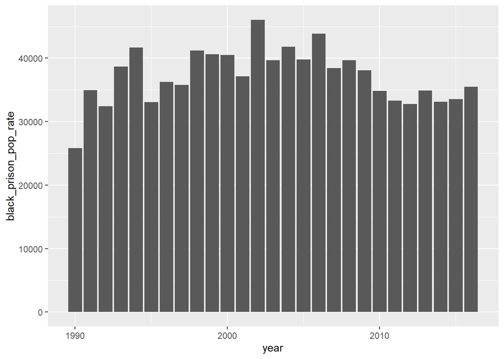

This chart represent the rate of the black population that is currently in prison. I choose this graph to represent the constant high rate representing people of color in prison. As shown in this graph, the rate started at low and then increases after a year then steady out at around the same amount. Due to the consistence of the graph, we know that the issues of incarceration rate for people of color hasn’t change over the past 30 years.

### Variable Comparison Chart

#### Washington State black prison rate vs white prison rate

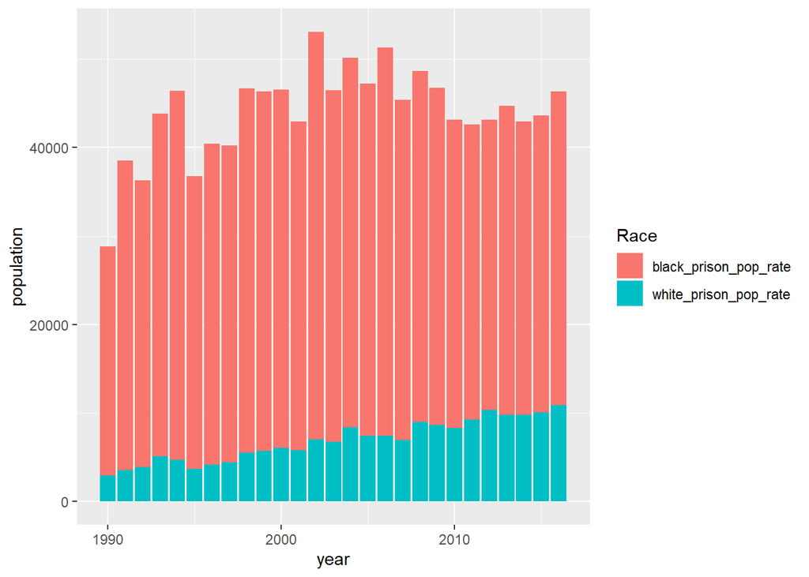

This rate compares the previous graph with an additional race. This graph is chosen to give context on the current trend of people of color. As you can see, white prison population rate is extremely low compare to blacks.

### Map

[figure not shown]

[figure not shown]